# Module 8 Project

Luis Caro

June 18, 2017

# Module 8 Project

## Purpose of the project

The goal of this project is to predict if an excercise is executed correclty, or what type of wrong execution was performed, based on data collected during the execution of the excercise. In this case, the excercise studied is barbell lifting, and The data collected came from accelerometers in the belt, arm, forearm, and dumbell of 6 participants.

The correct execution of the excercise is categorized in 5 levels, A to E. A corresponds to the excercise executed exactly as specified, and B to E, correspond to different ways of performing the excerscise incorrectly.

Devices such as Jawbone Up, Nike Fuelband, and Fitbid, probably could be used for the purpose of generating the data.

Detailed information of the study can be found at: http://groupware.les.inf.puc-rio.br/har .

## Data preparation

```r
library(ggplot2)
library(caret)
library(ggplot2)
library(AppliedPredictiveModeling)
library(Hmisc)
library(gbm)
pml.training<-read.csv("pml-training.csv")
pml.testing<-read.csv("pml-testing.csv")
```

The first 7 predictors were removed for the following reasons: - Column 1 (X) is the number of the row - Column 2 (user_name) is just the name - Columns 3,4,5 (raw_timestamp_part-1, raw_timestamp_part-2, and cvtd_timestamp) relate to times. Its meaning was not found in the documentation. Initially they were removed from the data. However, since the model produced good results without these predictors, they were permanently removed. - Columns 6 and (new_window and num_window) do not appear to be related with the way the excercise is performed. They were also removed.

```r
columnsWithFewNAs<-sapply(pml.training,function(x) sum(is.na(x)))<19216
length(columnsWithFewNAs[columnsWithFewNAs==TRUE])
```

```
## [1] 93
```

```r
pml.TrainingWONAs<-(pml.training[columnsWithFewNAs])[,c(-1,-2,-3,-4,-5,-6,-7)]
```

The last step was to remove predictors with near zero variance.

```r
nsv <- nearZeroVar(pml.TrainingWONAs,saveMetrics=TRUE)
pml.TrainingWONAs<-pml.TrainingWONAs[,nsv$nzv == FALSE]
```

As a result of the prior steps, the number of predictors was reduced from 159 to 52 predictors

## Cross validation

Throughout this project the training of the models was done using a 4-fold cross validation, except if indicated otherwise. The number 4 was selected to keep 25% of the observations as test data in each iteration. Based on This approach, the out-of-sample error was estimated for each case.

## Data exploration

It is dificult to visualize grafically the relationships between the prdictors an the result (‘classe’) when there are so many predictors. So it was decided to initilly build a tree model. The idea would be, based on the hierarchy of the nodes selected for the tree, get a feeling about what variables were the ones that at least had the most segregating power.

```r
modtree <- train(classe ~.,method="rpart",data=pml.TrainingWONAs,trControl = trainControl(method="cv",number=4))
```

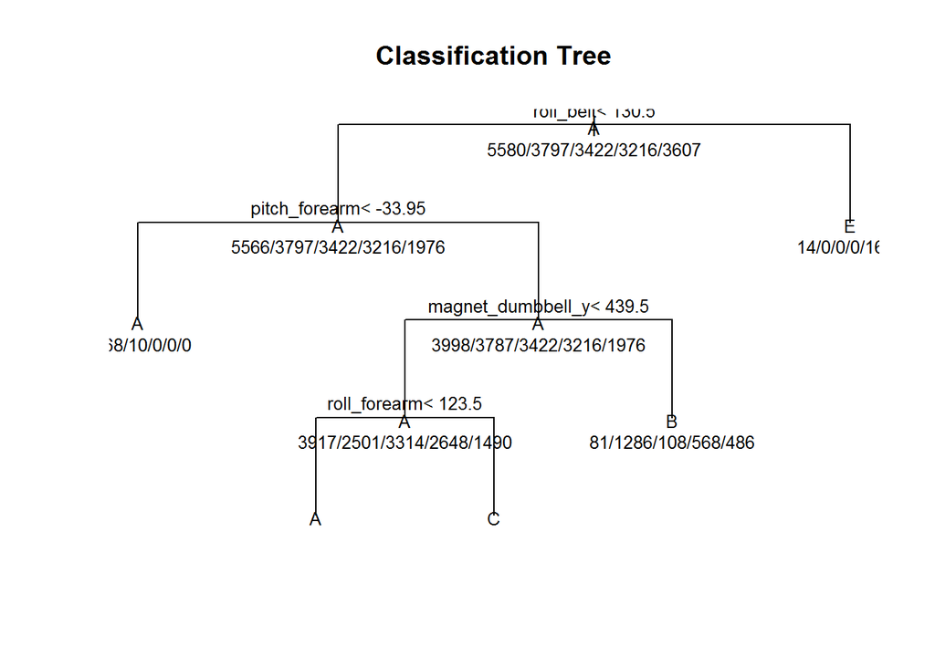

```r
plot(modtree$finalModel, uniform=TRUE, main="Classification Tree")
text(modtree$finalModel, use.n=TRUE, all=TRUE, cex=.8)
```

```r
print(modtree$finalModel)
```

```
## n= 19622
##
## node), split, n, loss, yval, (yprob)
##       * denotes terminal node
##
##  1) root 19622 14042 A (0.28 0.19 0.17 0.16 0.18)
##    2) roll_belt< 130.5 17977 12411 A (0.31 0.21 0.19 0.18 0.11)
##      4) pitch_forearm< -33.95 1578    10 A (0.99 0.0063 0 0 0) *
##      5) pitch_forearm>=-33.95 16399 12401 A (0.24 0.23 0.21 0.2 0.12)
##       10) magnet_dumbbell_y< 439.5 13870  9953 A (0.28 0.18 0.24 0.19 0.11)
##         20) roll_forearm< 123.5 8643  5131 A (0.41 0.18 0.18 0.17 0.061) *
##         21) roll_forearm>=123.5 5227  3500 C (0.077 0.18 0.33 0.23 0.18) *
##       11) magnet_dumbbell_y>=439.5 2529  1243 B (0.032 0.51 0.043 0.22 0.19) *
##    3) roll_belt>=130.5 1645    14 E (0.0085 0 0 0 0.99) *
```

```r
print(modtree)
```

```
## CART
##
## 19622 samples
##    52 predictor
##     5 classes: 'A', 'B', 'C', 'D', 'E'
##
## No pre-processing
## Resampling: Cross-Validated (4 fold)
## Summary of sample sizes: 14717, 14717, 14716, 14716
## Resampling results across tuning parameters:
##
##   cp          Accuracy   Kappa
##   0.03567868  0.5206926  0.38004910
##   0.05998671  0.3965924  0.17640427
##   0.11515454  0.3243339  0.06113676
##
## Accuracy was used to select the optimal model using  the largest value.
## The final value used for the model was cp = 0.03567868.
```

As explained in the course, the Random Forest model is very powerful for this type of problem. However, it has an important drawback that is the amount of time it consumes, specialy taking into consideration the large number of predictors. It was decided to run it once with all the predictors to attain what the target accuracy of the model could be.

```r
modrf <- train(classe ~.,method="rf",data=pml.TrainingWONAs,trControl = trainControl(method="cv",number=4))
print(modrf)
```

```
## Random Forest
##
## 19622 samples
##    52 predictor
##     5 classes: 'A', 'B', 'C', 'D', 'E'
##
## No pre-processing
## Resampling: Cross-Validated (4 fold)
## Summary of sample sizes: 14716, 14717, 14717, 14716
## Resampling results across tuning parameters:
##
##   mtry  Accuracy   Kappa
##    2    0.9943431  0.9928441
##   27    0.9936806  0.9920060
##   52    0.9879218  0.9847218
##
## Accuracy was used to select the optimal model using  the largest value.
## The final value used for the model was mtry = 2.
```

As can be seen in the output, the accuracy is over 99%.

It is important to mention that the processing lasted 16 minutes.

## Methodology

It was decided to take following steps:

### Apply PCA

It can be concluded from the tree model that not to many variables have a segregating value. One possible reason for this is that the predictors can be very correlated. Measurement of the correlations was made (see Appendix), and the result confirmed that there are many predictors with correlations with other predictors, above 80%.

It was decided to consider PCA. For this purpose we considered number of PCAs in multiples of 5 (ie. 5, 10, 15, etc,). The number of PCAs would be increased until the accuracy of the model was over 90%. The model used is Random Forest.

### Models considered

As explained above, the tree model was discarded given its hig out-of-sample error. Given the high level of accuracy that could be obtained with a Random Forest model, it was decided to use a Random Forest model.

Another model, boosting, was considered. Its results, as will be shown below, were not as good.

### Random forest model results

The first iteration with the model was considering 5 variables obtained under PCA.

```r
preProc5 <- preProcess(pml.TrainingWONAs[,-53],method="pca",pcaComp=5)
pml.PC5 <- predict(preProc5,pml.TrainingWONAs[,-53])
pml.PC5$classe<-pml.TrainingWONAs[,53]
modrfPCA5<-train(classe ~.,data=pml.PC5,method="rf",trControl = trainControl(method="cv",number=4))
print(modrfPCA5)
```

```
## Random Forest
##
## 19622 samples
##     5 predictor
##     5 classes: 'A', 'B', 'C', 'D', 'E'
##
## No pre-processing
## Resampling: Cross-Validated (4 fold)
## Summary of sample sizes: 14716, 14717, 14718, 14715
## Resampling results across tuning parameters:
##
##   mtry  Accuracy   Kappa
##   2     0.8528190  0.8137317
##   3     0.8485379  0.8083380
##   5     0.8390589  0.7963297
##
## Accuracy was used to select the optimal model using  the largest value.
## The final value used for the model was mtry = 2.
```

As it can be seen in the result, the accuracy is a little bit over 85%, and the process took around 2 minutes. Even though it is a good accuracy, another iteration was made with 10 PCAs.

```r
preProc10 <- preProcess(pml.TrainingWONAs[,-53],method="pca",pcaComp=10)
pml.PC10 <- predict(preProc10,pml.TrainingWONAs[,-53])
pml.PC10$classe<-pml.TrainingWONAs[,53]
modrfPCA10<-train(classe ~.,data=pml.PC10,method="rf",trControl = trainControl(method="cv",number=4))
print(modrfPCA10)
```

```
## Random Forest
##
## 19622 samples
##    10 predictor
##     5 classes: 'A', 'B', 'C', 'D', 'E'
##
## No pre-processing
## Resampling: Cross-Validated (4 fold)
## Summary of sample sizes: 14716, 14718, 14716, 14716
## Resampling results across tuning parameters:
##
##   mtry  Accuracy   Kappa
##    2    0.9589233  0.9480339
##    6    0.9539796  0.9417955
##   10    0.9487814  0.9352258
##
## Accuracy was used to select the optimal model using  the largest value.
## The final value used for the model was mtry = 2.
```

### Boosting results

As an alternative Boosting was considered. The results are the following:

Aas can be seen in the results, the obtained accuracy is 73%, much lower than the accuracy of the Random Forest model.

```r
modBoostPCA10 <- train(classe ~ ., method="gbm",data=pml.PC10,verbose=FALSE,trControl = trainControl(method="cv",number=4))
print(modBoostPCA10)
```

```
## Stochastic Gradient Boosting
##
## 19622 samples
##    10 predictor
##     5 classes: 'A', 'B', 'C', 'D', 'E'
##
## No pre-processing
## Resampling: Cross-Validated (4 fold)
## Summary of sample sizes: 14717, 14717, 14715, 14717
## Resampling results across tuning parameters:
##
##   interaction.depth  n.trees  Accuracy   Kappa
##   1                   50      0.4964316  0.3529445
##   1                  100      0.5379675  0.4104575
##   1                  150      0.5588111  0.4380008
##   2                   50      0.5801652  0.4668036
##   2                  100      0.6389261  0.5420954
##   2                  150      0.6713897  0.5837570
##   3                   50      0.6272553  0.5278408
##   3                  100      0.6953423  0.6141865
##   3                  150      0.7342275  0.6634313
##
## Tuning parameter 'shrinkage' was held constant at a value of 0.1
##
## Tuning parameter 'n.minobsinnode' was held constant at a value of 10
## Accuracy was used to select the optimal model using  the largest value.
## The final values used for the model were n.trees = 150,
##  interaction.depth = 3, shrinkage = 0.1 and n.minobsinnode = 10.
```

# Appendix

## Correlations among predictors

```r
M <- abs(cor(pml.TrainingWONAs[,-53]))
diag(M) <- 0
which(M > 0.8,arr.ind=T)
```

```
##                  row col
## yaw_belt           3   1
## total_accel_belt   4   1
## accel_belt_y       9   1
## accel_belt_z      10   1
## accel_belt_x       8   2
## magnet_belt_x     11   2
## roll_belt          1   3
## roll_belt          1   4
## accel_belt_y       9   4
## accel_belt_z      10   4
## pitch_belt         2   8
## magnet_belt_x     11   8
## roll_belt          1   9
## total_accel_belt   4   9
## accel_belt_z      10   9
## roll_belt          1  10
## total_accel_belt   4  10
## accel_belt_y       9  10
## pitch_belt         2  11
## accel_belt_x       8  11
## gyros_arm_y       19  18
## gyros_arm_x       18  19
## magnet_arm_x      24  21
## accel_arm_x       21  24
## magnet_arm_z      26  25
## magnet_arm_y      25  26
## accel_dumbbell_x  34  28
## accel_dumbbell_z  36  29
## gyros_dumbbell_z  33  31
## gyros_forearm_z   46  31
## gyros_dumbbell_x  31  33
## gyros_forearm_z   46  33
## pitch_dumbbell    28  34
## yaw_dumbbell      29  36
## gyros_forearm_z   46  45
## gyros_dumbbell_x  31  46
## gyros_dumbbell_z  33  46
## gyros_forearm_y   45  46
```